# Analysis of Q-Exactive MS2 iTRAQ data from Martinez-Val *et al.*

Christopher Hughes

### Description

This file contains the code for processing the search and quantification output files from the iTRAQ proteome mixture publication from Martinez-Val *et al.* (PMID: 27452035). **These data were used to make Figure S-6.**

- MGF files were generated using RawQuant.
- The data were searched using SearchCLI and PeptideShakerCLI.
- Raw files were quantified with RawQuant and Proteome Discoverer in parallel.

### Analysis

First call the required libraries.

```r
library(Biostrings)
library(dplyr)
library(ggplot2)
library(RColorBrewer)
library(cowplot)
library(reshape)
```

Next we want to make an index based on our search database that we can use to add descriptive data to our search result.

```r
####
mixDB = readAAStringSet('/projects/ptx_analysis/chughes/databases/uniprot_human-ecoli-crap-oct2017-FWD.fasta')
#make an annotation index from the human and e coli mixture database
mixIndex = data.frame('meta' = names(mixDB))
mixIndex$accession = sub(".*?\\|(.*?)\\|.*", "\\1", mixIndex$meta) #grab the accession from the header
mixIndex$gene = sub(".*?GN=(.*?) .*", "\\1", mixIndex$meta) #grab the gene from the header
mixIndex$species = sub(".*?OS=(.*?) [GP].*", "\\1", mixIndex$meta) #grab the species from the header
mixIndex = mixIndex[,2:4]
```

Now we can go ahead and grab the identification and quantification data.

```r
#find the files of interest
#psms files from SearchCLI and PeptideShaker
psm_files = list.files('/projects/ptx_results/OtherDataSets/2016-July_Munoz_JPro/reports-output',pattern='*Default_PSM_Report.txt',full.names=TRUE)
#quant files from RawQuant algorithm
quant_files = list.files('/projects/ptx_results/OtherDataSets/2016-July_Munoz_JPro/quant-output',pattern='*QuantData.txt',full.names=TRUE)
#quant files from Proteome Discoverer
pd_files = list.files('/projects/ptx_results/OtherDataSets/2016-July_Munoz_JPro/pd-quant-output',pattern='*QuanSpectra.txt',full.names=TRUE)
```

Now we can process the peptide spectral match data to a more manageable data frame, and incorporate the quantification data from the two different sources.

```r
psm_all = data.frame() #create an empty data frame to hold the output data
#iterate over all the psm files
for (i in 1:length(psm_files)){

  ###this first section handles the identification data
  psm_in = read.table(psm_files[i],header=TRUE,sep='\t') #grab the input file
  psm_f1 = psm_in %>%
    dplyr::select(Protein.s., Sequence, Spectrum.File, Spectrum.Title, m.z, Identification.Charge) %>% #select columns
    dplyr::mutate(Spectrum.Title, scan_num = sub(".*?spectrum (.*?)", "\\1", Spectrum.Title)) %>% #parse out the scan number
    dplyr::mutate(Identification.Charge, id_charge = gsub("[^0-9]", "", Identification.Charge)) %>% #parse out the charge
    dplyr::mutate(Spectrum.Title, fraction = sub(".*?Isolationexp_(.*?)_.*", "\\1", Spectrum.File)) %>% #parse the fraction
    dplyr::mutate(Spectrum.Title, replicate = sub(".*?Isolationexp_(.*?)_MGF\\.mgf", "\\1", Spectrum.File)) %>% #parse the replicate
    dplyr::select(Protein.s., Sequence, scan_num, m.z, id_charge, fraction, replicate) %>% #select new columns
    dplyr::mutate(Protein.s., first_accession = sapply(strsplit(as.character(Protein.s.),"\\,"), `[`, 1)) #parse the accession
  #adjust the column names
  colnames(psm_f1) = c('accession_groups','sequence','ScanNumber','id_precursor_mz','id_charge','fraction','replicate','accession')
  psm_f2 = merge(psm_f1,mixIndex,by='accession',all.x=TRUE) #add the descriptive data
  psm_f3 = dplyr::filter(psm_f2, !grepl('CONT', accession)) #remove contaminant hits


  ####this second section handles the RawQuant quantification data
  quant_in = read.table(quant_files[i],header=TRUE,sep='\t') #grab the input file
  quant_in[,9:56][quant_in[,9:56] == 0] = NA #transform any zero or missing values to NA
  quant_f1 = subset(quant_in, rowSums(is.na(quant_in[,c('iTRAQ113_intensity','iTRAQ114_intensity','iTRAQ115_intensity',
                                                        'iTRAQ116_intensity','iTRAQ117_intensity','iTRAQ118_intensity',
                                                        'iTRAQ119_intensity','iTRAQ121_intensity')])) < 8) #calculate how many scans have zero reporters
  message('number of scans without reporter ion signals = ', nrow(quant_in) - nrow(quant_f1)) #output message
  quant_meta = quant_in[,c('PrecursorMass','ScanNumber','MS1ScanNumber','RetentionTime',
                           'PrecursorCharge','MS2IonInjectionTime','MS1Interference')] #extract the quantification meta data
  quant_exprs = quant_in[,c('iTRAQ113_intensity','iTRAQ114_intensity','iTRAQ115_intensity','iTRAQ116_intensity',
                            'iTRAQ117_intensity','iTRAQ118_intensity','iTRAQ119_intensity','iTRAQ121_intensity',
                            'iTRAQ113_noise','iTRAQ114_noise','iTRAQ115_noise','iTRAQ116_noise','iTRAQ117_noise',
                            'iTRAQ118_noise','iTRAQ119_noise','iTRAQ121_noise')] #extract the quantification data
  quant_sn = quant_exprs[,c(1:8)] / quant_exprs[,c(9:16)] #calculate the signal to noise
  quant_sn$totalIntensity = rowSums(quant_exprs[,1:8],na.rm=TRUE) #calculate the total sum intensity
  quant_sn$totalSN = rowSums(quant_sn[,1:8],na.rm=TRUE) #calculate the total sum signal to noise
  quant_sn$totalNoise = rowSums(quant_exprs[,9:16],na.rm=TRUE) #calculate the total sum noise
  quant_sn$totalNA = rowSums(is.na(quant_sn[,1:8])) #grab the number of NA values across the TMT channels
  quant_meta$fraction = sub(".*?Isolationexp_(.*?)_.*", "\\1", quant_files[i]) #add a fraction column
  quant_matrix = cbind(quant_meta,quant_sn) #combined the meta and final expression data



  ####this third section handles the Proteome Discoverer quantification data
  pd_in = read.table(pd_files[i],header=TRUE,sep='\t') #grab the input file
  colnames(pd_in) = c('Checked','BestPSMAmbiguity','Analyzer','ActivationType','MSOrder','NumberOfPSMs',
                      'pd_MS1Interference','pd_MS3IonInjectionTime','pd_PrecursorMass','mono','pd_PrecursorCharge',
                      'pd_RetentionTime','ScanNumber','fraction','pd_meanSN','pd_113','pd_114','pd_115','pd_116',
                      'pd_117','pd_118','pd_119','pd_121') #reassign column names
  pd_in$fraction = sub(".*?Isolationexp_(.*?)_.*", "\\1", pd_in$fraction) #add a fraction column

  ####this section merges all of the data together
  psm_quant1 = merge(psm_f3,quant_matrix, by=c('ScanNumber','fraction'),all.x=TRUE) #merge the identifications with RawQuant data
  psm_quant2 = merge(psm_quant1,pd_in,by=c('ScanNumber','fraction'),all.x=TRUE) #merge with Proteome Discoverer data
  psm_all = rbind(psm_all,psm_quant2) #bind all the data into a continuous single set

  message('finished ',i,' files') #output message for tracking progress
}
#save the output data frame for later use
saveRDS(psm_all, '/projects/ptx_analysis/chughes/projects-current/raw-quant/published-data/munoz_iTRAQ/Routput/munoz-itraq_all-psms-id-quant.rds')
```

First we can look at the ‘compressed’ vs. ‘uncompressed’ channel values to see if they line up with published data.

```r
id_table = readRDS('/projects/ptx_analysis/chughes/projects-current/raw-quant/published-data/munoz_iTRAQ/Routput/munoz-itraq_all-psms-id-quant.rds')
#use the 2p0 replicates for this, as that is what was used in the paper, and only ecoli peptides
id_2p0 = subset(id_table, grepl('2p0', id_table$fraction) & grepl('coli', id_table$species)) #grab the correct PSMs
#calculate the log2 ratios of the compressed (113/115) and uncompressed (117/119) channels
id_2p0$compressed = log2(id_2p0$iTRAQ113_intensity / id_2p0$iTRAQ115_intensity) #calculate compressed ratios
id_2p0$uncompressed = log2(id_2p0$iTRAQ117_intensity / id_2p0$iTRAQ119_intensity) #calculate uncompressed ratios
#plot the resulting values
compress_plot = ggplot(melt(id_2p0[,50:51]), aes(variable,value)) +
  geom_point(aes(fill=variable),position=position_jitterdodge(dodge.width=0.9),colour='grey80',alpha=0.4) +
  geom_boxplot(aes(fill=variable),fill='white',outlier.colour=NA,position=position_dodge(width=0.9)) +
  labs(x = "iTRAQ Channels", y = 'log2 ratio', title = 'iTRAQ Ratio Compression') +
  theme(axis.text.x = element_text(hjust = 1, size = 9)) +
  scale_y_continuous(limits=c(-0.5,2.5),breaks=seq(-0.5,2.5,0.5)) +
  theme(legend.position="none") +
  geom_hline(yintercept = log2(2.5),linetype='dashed',colour=brewer.pal(6,'RdBu')[1])
```

```
Using  as id variables
```

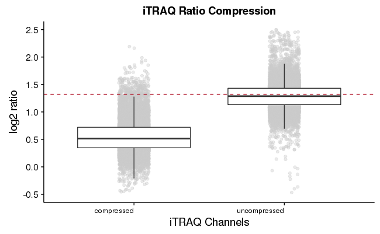

```r
compress_plot #call the plot
save_plot('/projects/ptx_analysis/chughes/projects-current/raw-quant/published-data/munoz_iTRAQ/Routput/munoz_compression_boxplot.pdf',compress_plot) #save the plot
```

```r
#grab a p-value for the comparison
compress_test = lm(compressed ~ uncompressed, data = id_2p0)
summary(compress_test) #hmm...the linear model doesn't seem to work well here. We can try a simple t-test
```

```
Call:
lm(formula = compressed ~ uncompressed, data = id_2p0)

Residuals:
     Min       1Q   Median       3Q      Max
-2.39739 -0.20710 -0.03791  0.16659  1.63577

Coefficients:
             Estimate Std. Error t value Pr(>|t|)
(Intercept)  0.552123   0.013858  39.842   <2e-16 ***
uncompressed 0.001429   0.010497   0.136    0.892
---
Signif. codes:  0 ‘***’ 0.001 ‘**’ 0.01 ‘*’ 0.05 ‘.’ 0.1 ‘ ’ 1

Residual standard error: 0.3062 on 11448 degrees of freedom
  (22 observations deleted due to missingness)
Multiple R-squared:  1.618e-06, Adjusted R-squared:  -8.573e-05
F-statistic: 0.01853 on 1 and 11448 DF,  p-value: 0.8917
```

```r
t.test(id_2p0$compressed,id_2p0$uncompressed) #perform the standard t-test
```

```
    Welch Two Sample t-test

data:  id_2p0$compressed and id_2p0$uncompressed
t = -192.59, df = 22619, p-value < 2.2e-16
alternative hypothesis: true difference in means is not equal to 0
95 percent confidence interval:
 -0.7454859 -0.7304647
sample estimates:
mean of x mean of y
0.5536901 1.2916654
```

```r
t.test(id_2p0$compressed, conf.level = 0.95) #get the confidence interval for the compressed data
```

```
    One Sample t-test

data:  id_2p0$compressed
t = 193.43, df = 11470, p-value < 2.2e-16
alternative hypothesis: true mean is not equal to 0
95 percent confidence interval:
 0.5480790 0.5593011
sample estimates:
mean of x
0.5536901
```

```r
t.test(id_2p0$uncompressed, conf.level = 0.95) #get the confidence interval for the uncompressed data
```

```
    One Sample t-test

data:  id_2p0$uncompressed
t = 507.07, df = 11450, p-value < 2.2e-16
alternative hypothesis: true mean is not equal to 0
95 percent confidence interval:
 1.286672 1.296658
sample estimates:
mean of x
 1.291665
```

Compare with reported expression values from their paper and Proteome Discoverer.

```r
#grab the published data for one of the 2p0 replicates
munoz_exprs = read.table('/projects/ptx_results/OtherDataSets/2016-July_Munoz_JPro/expression-tables/QExactive_2p0_rep05.txt',header=TRUE,sep='\t')
colnames(munoz_exprs)[1] = 'sequence' #change a column name for merging purposes
munoz_exprs$sequence = toupper(munoz_exprs$sequence) #reshape the peptide data to remove modifications
id_2p0 = subset(id_table, grepl('2p0_05', id_table$replicate) & grepl('coli', id_table$species)) #grab the RawQuant data
munoz_id = merge(munoz_exprs, id_2p0, by='sequence') #merge the two sets by their peptide sequences
quant_matrix = as.matrix(cor(munoz_id[,6:13],munoz_id[,37:44],use='pairwise.complete.obs',method='pearson')) #get correlation
quant_matrix #call the correlation matrix
```

```
     iTRAQ113_intensity iTRAQ114_intensity iTRAQ115_intensity iTRAQ116_intensity iTRAQ117_intensity iTRAQ118_intensity iTRAQ119_intensity iTRAQ121_intensity
X113         0.12369110         0.10846869        0.050678447         0.06392247          0.1823004          0.1897674          0.1701796          0.1867082
X114         0.12566818         0.11913226        0.060348526         0.07292871          0.1856370          0.1881293          0.1713354          0.1854401
X115         0.14974978         0.14599672        0.102607411         0.10920800          0.1741257          0.1733074          0.1640296          0.1700952
X116         0.15130041         0.14551744        0.096342305         0.11721168          0.1732705          0.1713776          0.1626183          0.1692423
X117         0.09350119         0.07999189        0.011236352         0.02161545          0.2104791          0.2156700          0.1905311          0.2121446
X118         0.08213538         0.06614684        0.002378752         0.01171945          0.1905435          0.2088849          0.1723943          0.2041864
X119         0.09527698         0.07985421        0.012540863         0.02264437          0.2048918          0.2121112          0.2016850          0.2093267
X121         0.08483988         0.06904771        0.004995619         0.01500490          0.1917442          0.2083766          0.1741685          0.2067527
```

```r
#hmm...this is pretty low...much lower than I would expect.
#what about with our own Proteome Discoverer data
quant_matrix = as.matrix(cor(id_2p0[,17:24],id_2p0[,42:49],use='pairwise.complete.obs',method='pearson')) #get correlation
quant_matrix #call the correlation matrix
```

```
                      pd_113    pd_114    pd_115    pd_116    pd_117    pd_118    pd_119    pd_121
iTRAQ113_intensity 0.9996354 0.9738245 0.9110325 0.9253564 0.7551460 0.6975204 0.7358911 0.7001431
iTRAQ114_intensity 0.9728911 0.9996591 0.9545966 0.9544830 0.7035117 0.6239268 0.6796397 0.6274133
iTRAQ115_intensity 0.9077049 0.9521548 0.9997058 0.9682379 0.5139273 0.4235501 0.5002692 0.4256197
iTRAQ116_intensity 0.9226452 0.9526328 0.9686874 0.9997034 0.5200555 0.4345877 0.5018867 0.4390896
iTRAQ117_intensity 0.7650322 0.7134983 0.5233185 0.5290764 0.9997343 0.9635585 0.9564274 0.9576938
iTRAQ118_intensity 0.7078831 0.6340508 0.4325884 0.4433318 0.9649772 0.9997975 0.9323751 0.9873123
iTRAQ119_intensity 0.7463962 0.6901547 0.5100801 0.5112827 0.9575001 0.9320093 0.9997952 0.9280513
iTRAQ121_intensity 0.7099322 0.6369566 0.4341030 0.4472606 0.9584670 0.9867008 0.9277690 0.9998219
```

```r
#hmm...this is almost perfect
#wonder why they disagree? Old software vs. new? Seems they did some other transformations in isobar...not really clear exactly what.
```

Done.